# Global Disease Burden Analysis

qwertz19 (https://github.com/pscprz)

# Introduction

The source data is from the Institute for Health Metrics and Evaluation (IHME) Global Burden of Disease (GBD) study.

# Communicable, Maternal, Neonatal, and Nutritional Disease Burden (CMNN)

## Table of Estimates for CMNN Burden Over Time

| Year | Canada | Germany | Mexico |
| --- | --- | --- | --- |
| 1990 | 1628.468 | 1581.431 | 9556.953 |
| 1991 | 1610.870 | 1534.790 | 9019.454 |
| 1992 | 1612.841 | 1468.267 | 8550.553 |
| 1993 | 1645.592 | 1438.674 | 8126.727 |
| 1994 | 1657.691 | 1409.525 | 7676.243 |
| 1995 | 1688.159 | 1355.051 | 7334.997 |
| 1996 | 1606.021 | 1304.176 | 6988.380 |
| 1997 | 1510.585 | 1252.101 | 6616.230 |
| 1998 | 1459.720 | 1219.134 | 6251.836 |
| 1999 | 1430.180 | 1209.316 | 5908.323 |
| 2000 | 1411.585 | 1191.178 | 5584.335 |
| 2001 | 1405.815 | 1185.846 | 5335.682 |
| 2002 | 1404.138 | 1184.905 | 5146.172 |
| 2003 | 1414.346 | 1191.913 | 4974.931 |
| 2004 | 1409.524 | 1180.416 | 4787.616 |
| 2005 | 1425.077 | 1169.103 | 4646.049 |
| 2006 | 1400.238 | 1161.764 | 4478.685 |
| 2007 | 1398.456 | 1165.466 | 4355.398 |
| 2008 | 1385.593 | 1151.658 | 4271.180 |
| 2009 | 1368.834 | 1145.662 | 4189.551 |
| 2010 | 1364.836 | 1134.785 | 4052.977 |
| 2011 | 1340.388 | 1132.113 | 3941.285 |
| 2012 | 1332.894 | 1106.245 | 3846.740 |
| 2013 | 1336.585 | 1100.323 | 3773.981 |
| 2014 | 1315.221 | 1085.785 | 3677.438 |
| 2015 | 1301.372 | 1097.201 | 3576.541 |
| 2016 | 1294.945 | 1103.710 | 3469.553 |
| 2017 | 1277.019 | 1063.944 | 3399.685 |
| 2018 | 1266.891 | 1048.096 | 3334.861 |
| 2019 | 1254.503 | 1036.394 | 3246.791 |

## Plot Showing Trends in CMNN Burden Over Time

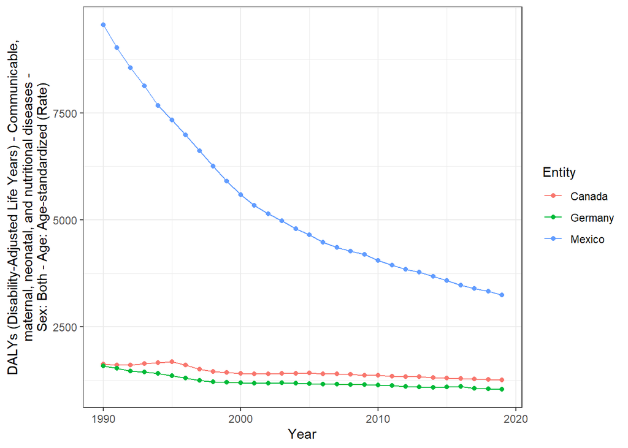

## Attribution

This section was completed by *qwertz19*.

The link to the group’s GitHub repository is https://github.com/pscprz/rmc_week_02_workshop

# Non-Communicable Disease Burden (NCD)

## Table of Estimates for NCD Burden Over Time

| Year | Canada | Germany | Mexico |
| --- | --- | --- | --- |
| 1990 | 19593.93 | 22295.99 | 22537.01 |
| 1991 | 19377.91 | 22123.93 | 22329.99 |
| 1992 | 19209.89 | 21812.48 | 22260.66 |
| 1993 | 19149.74 | 21663.98 | 22256.58 |
| 1994 | 19003.90 | 21399.01 | 22176.27 |
| 1995 | 18860.08 | 21137.76 | 22186.60 |
| 1996 | 18655.65 | 20876.58 | 22049.21 |
| 1997 | 18457.68 | 20545.63 | 22027.22 |
| 1998 | 18276.44 | 20215.48 | 21956.94 |
| 1999 | 18076.19 | 19945.16 | 21688.58 |
| 2000 | 17862.21 | 19696.00 | 21374.95 |
| 2001 | 17679.90 | 19458.42 | 21172.42 |
| 2002 | 17536.40 | 19366.27 | 21218.73 |
| 2003 | 17390.18 | 19251.49 | 21235.68 |
| 2004 | 17198.10 | 18892.57 | 20959.42 |
| 2005 | 17049.11 | 18653.50 | 21051.60 |
| 2006 | 16861.82 | 18425.73 | 20786.44 |
| 2007 | 16789.43 | 18281.95 | 20643.53 |
| 2008 | 16682.26 | 18173.17 | 20912.38 |
| 2009 | 16539.79 | 18057.93 | 21046.65 |
| 2010 | 16379.09 | 17892.32 | 20727.01 |
| 2011 | 16225.64 | 17744.34 | 20488.73 |
| 2012 | 16165.93 | 17627.35 | 20460.09 |
| 2013 | 16102.23 | 17617.39 | 20763.36 |
| 2014 | 16093.64 | 17448.14 | 20788.63 |
| 2015 | 16054.63 | 17534.20 | 20715.05 |
| 2016 | 16161.82 | 17451.40 | 20807.49 |
| 2017 | 16233.64 | 17331.07 | 21077.82 |
| 2018 | 16335.44 | 17291.55 | 21024.09 |
| 2019 | 16352.54 | 17277.05 | 21022.82 |

## Plot Showing Trends in NCD Burden Over Time

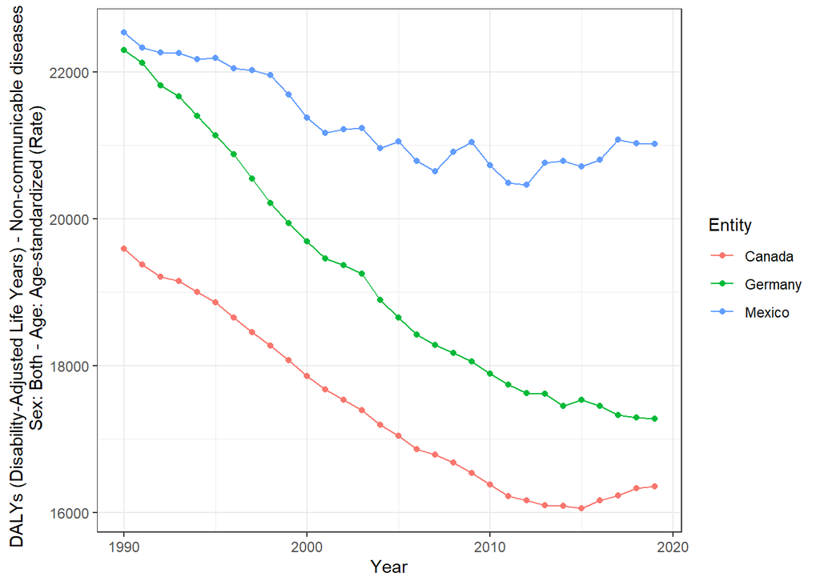

## Summary of NCD Burden Findings

Again, both Canada and Germany exhibit the same decreasing trend.

In Mexico, values are much higher and fluctuate from 2000.

## Attribution

This section was completed by *qwertz19*.

The link to the group’s GitHub repository is https://github.com/pscprz/rmc_week_02_workshop

# Overall Disease Burden

## Table of Estimates for Overall Disease Burden Over Time

| Year | Canada | Germany | Mexico |
| --- | --- | --- | --- |
| 1990 | 24247.51 | 26732.42 | 37352.90 |
| 1991 | 23945.82 | 26500.18 | 36358.29 |
| 1992 | 23714.16 | 26045.71 | 35598.10 |
| 1993 | 23642.44 | 25804.22 | 34959.64 |
| 1994 | 23450.78 | 25461.21 | 34250.38 |
| 1995 | 23278.25 | 25099.20 | 33736.92 |
| 1996 | 22934.07 | 24728.42 | 33100.04 |
| 1997 | 22589.91 | 24260.00 | 32648.71 |
| 1998 | 22315.44 | 23815.04 | 32213.37 |
| 1999 | 22045.29 | 23470.49 | 31447.75 |
| 2000 | 21747.44 | 23137.66 | 30657.01 |
| 2001 | 21524.03 | 22814.83 | 30098.60 |
| 2002 | 21343.27 | 22676.03 | 29932.84 |
| 2003 | 21177.78 | 22516.73 | 29756.46 |
| 2004 | 20944.65 | 22063.44 | 29206.45 |
| 2005 | 20810.98 | 21747.46 | 29191.59 |
| 2006 | 20561.00 | 21463.56 | 28754.94 |
| 2007 | 20460.28 | 21289.70 | 28478.14 |
| 2008 | 20312.80 | 21141.56 | 28876.06 |
| 2009 | 20108.18 | 21007.76 | 29090.65 |
| 2010 | 19913.87 | 20819.46 | 28655.61 |
| 2011 | 19691.03 | 20643.51 | 28296.80 |
| 2012 | 19613.58 | 20467.08 | 28073.73 |
| 2013 | 19536.04 | 20436.08 | 28269.27 |
| 2014 | 19506.11 | 20234.97 | 28087.14 |
| 2015 | 19461.48 | 20351.35 | 27903.89 |
| 2016 | 19591.00 | 20295.31 | 28013.45 |
| 2017 | 19636.54 | 20152.54 | 28524.92 |
| 2018 | 19705.53 | 20099.16 | 28332.93 |
| 2019 | 19683.72 | 20075.12 | 28055.23 |

## Plot Showing Trends in Overall Disease Burden Over Time

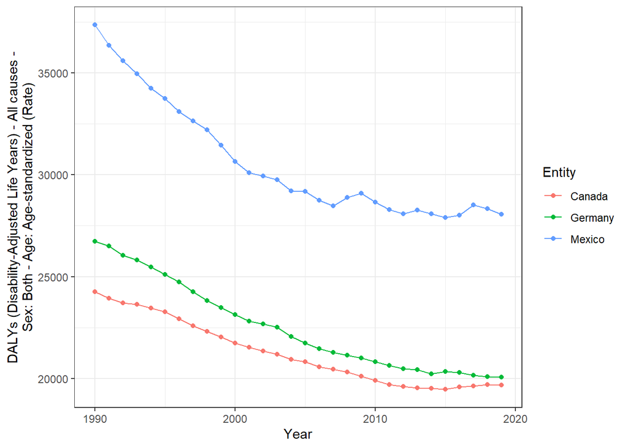

## Summary of Overall Disease Burden Findings

All three countries exhibit a decreasing trend over time. Nevertheless, Mexico surpasses both Germany and Canada by far. Also there are slight fluctuation from 2005.

Canada registered the lowest values of the three countries over time, being followed by Germany, specially from 2010 onwards.

## Attribution

This section was completed by *qwertz19*.

The link to the group’s GitHub repository is https://github.com/pscprz/rmc_week_02_workshop